# Week 7: Python Functions and Control Flow, Law of Large Numbers

## DSUA111: Data Science for Everyone, NYU, Fall 2020

### TA Jeff, `jpj251@nyu.edu`

- This slideshow: https://jjacobs.me/dsua111-sections/week-07
- All materials: https://github.com/jpowerj/dsua111-sections

## Outline

**[Part 1: Python]**

1. Functions
2. Conditional Statements
3. Loops

**[Part 2: Not Python]**

1. Sampling and Law of Large Numbers

# Part 1: Python

## Functions

- Built-In Functions
- Imported Functions
- Make Your Own!

## Built-In Functions

```python
print("hi")
```

```
hi
```

```python
float("infinity")
```

```
inf
```

```python
type(float("infinity"))
```

```
float
```

## Imported Functions

```python
my_list = [1,2,3,4,5]
```

```python
my_list.sum()
```

```
---------------------------------------------------------------------------
AttributeError                            Traceback (most recent call last)
<ipython-input-95-ed142f2087a1> in <module>
----> 1 my_list.sum()

AttributeError: 'list' object has no attribute 'sum'
```

noooooooooo

```python
import numpy as np
```

```python
my_array = np.array(my_list)
```

```python
my_array.sum()
```

```
15
```

yayyyyyyyyyy

## Make Your Own!

```python
def how_many_letters():
    return len("abcdefghijklmnopqrstuvwxyz")
```

...No output?

```python
how_many_letters()
```

```
26
```

What does this function return?

```python
fn_result = how_many_letters()
print(fn_result)
```

```
26
```

```python
print(type(fn_result))
```

```
<class 'int'>
```

## Printing Is Not Returning!!!

```python
def say_hi():
    print("hi")
```

```python
say_hi()
```

```
hi
```

What does this function return?

```python
hi_result = say_hi()
```

```
hi
```

```python
print(hi_result)
```

```
None
```

```python
print(type(hi_result))
```

```
<class 'NoneType'>
```

Instead...

```python
def return_hi():
    return "hi"
```

```python
return_hi()
```

```
'hi'
```

What does this function return?

```python
hi_result_2 = return_hi()
```

```python
print(hi_result_2)
```

```
hi
```

```python
print(type(hi_result_2))
```

```
<class 'str'>
```

I know this is a ten year old meme and that teachers using memes is one of the lamest things in the universe but... i had to do it

[figure not shown]

## Make Your Own! With Parameters!

```python
def triple(the_number):
    return 3 * the_number
```

```python
triple(5)
```

```
15
```

```python
triple(0)
```

```
0
```

```python
triple(triple(5))
```

```
45
```

Can do more than one!

```python
def combine_names(first_name, second_name, third_name):
    return first_name + ", " + second_name + ", and " + third_name
```

```python
combine_names("Alice", "Bob", "Craig")
```

```
'Alice, Bob, and Craig'
```

(https://en.wikipedia.org/wiki/Alice_and_Bob)

## Conditional Statements

- Called "Control Flow Statements" (https://en.wikipedia.org/wiki/Control_flow)
- Until now, Python ran every line you wrote, from top of cell to bottom, in order
- Now you can control which lines get run, *conditionally*
- `if`, `if-else`, `if-elif-else` (really `if-elif-...-elif-else`)

## `if` Statements

```
if condition:
    expression(s)
```

[figure not shown]

(Lecture 12.3, Slide 6)

## `if-else`

```
if condition_1:
    expression_1
else:
    expression_2
```

[figure not shown]

(Lecture 12.3, Slide 7)

## `if-elif-...-elif-else`

```
if condition_1:
    expression_1
elif condition_2:
    expression_2
...
elif condition_10:
    expression_10
else:
    expression_11
```

[figure not shown]

(Lecture 12.3, Slide 8)

## **`while`** Loops

```
while condition:
    expression
```

[figure not shown]

(Lecture 12.2, Slide 12)

(tl;dr: **While** $X$ is true, do $Y$)

```python
i = 0
while i < 10:
    print(i)
    i = i + 1
```

```
0
1
2
3
4
5
6
7
8
9
```

```python
my_list = ["Afghanistan", "Albania", "Algeria", "Yemen", "Zambia", "Zimbabwe"]
```

```python
list_index = 0
while list_index < len(my_list):
    current_thing = my_list[list_index]
    print("Item #" + str(list_index) + " is " + str(current_thing))
    list_index = list_index + 1
```

```
Item #0 is Afghanistan
Item #1 is Albania
Item #2 is Algeria
Item #3 is Yemen
Item #4 is Zambia
Item #5 is Zimbabwe
```

That's a lot of gross-looking code...

## **`for`** Loops

```
for element in sequence:
    expression
```

[figure not shown]

(tl;dr: **For** each thing in $X$, do $Y$)

```python
for current_thing in my_list:
    print(current_thing)
```

```
Afghanistan
Albania
Algeria
Yemen
Zambia
Zimbabwe
```

```python
for list_index, current_thing in enumerate(my_list):
    print("Element #" + str(list_index) + " is " + str(current_thing))
```

```
Element #0 is Afghanistan
Element #1 is Albania
Element #2 is Algeria
Element #3 is Yemen
Element #4 is Zambia
Element #5 is Zimbabwe
```

# Part 2: Not Python

## Sampling

- **Population**: Full set of things we want to draw inferences about
- **Sample**: Actual set of observations of these things that we have to work with

[figure not shown]

(from https://www.statsandr.com/blog/what-is-the-difference-between-population-and-sample/)

## Sampling With and Without Replacement

- **Sampling With Replacement**: People/units can enter the sample more than once
- **Sampling Without Replacement**: People/units enter the same **at most** once

[figure not shown]

(from https://slidewiki.org/deck/1290-2/data-reduction/slide/10562-2/10562-2:21/view)

## Distributions

- **Probability Distribution**: Theoretical -- I expect that each side of the die will come up 1/6th of the time
- **Empirical Distribution**: Actually observed -- I rolled the die 10 times and saw this many 1s, this many 2s, ...

## Plotting a Distribution

```python
import matplotlib.pyplot as plt
def plot_distribution():
    die_faces = [1,2,3,4,5,6]
    probabilities = [1/6,1/6,1/6,1/6,1/6,1/6]
    plt.bar(die_faces, probabilities)
    plt.show()
```

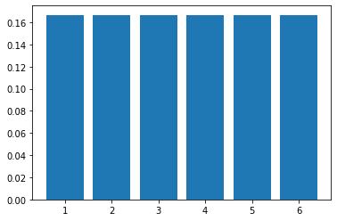

```python
plot_distribution()
```

```python
1/6
```

```
0.16666666666666666
```

## Law of Large Numbers

[figure not shown]

(from https://alphaarchitect.com/2014/01/04/the-law-of-large-numbers-and-casino-earnings/)

## N = 10

```python
import numpy as np
```

```python
# N = 10
rolls = np.random.randint(1, 7, 10)
print(rolls)
more_rolls = np.random.randint(1, 7, 10)
print(more_rolls)
even_more_rolls = np.random.randint(1, 7, 10)
print(even_more_rolls)
```

```
[2 2 4 3 1 6 2 1 2 6]
[2 6 5 5 4 5 3 4 6 6]
[5 2 3 3 6 6 3 3 2 5]
```

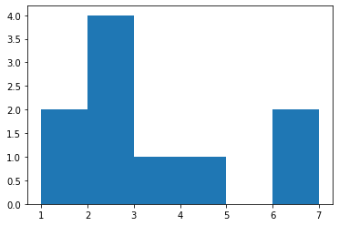

```python
plt.hist(rolls, bins=range(1,8))
plt.show()
```

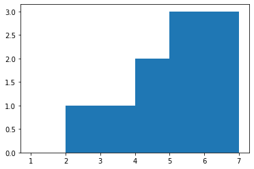

```python
plt.hist(more_rolls, bins=range(1,8))
plt.show()
```

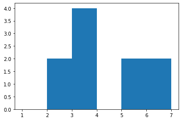

```python
plt.hist(even_more_rolls, bins=range(1,8))
plt.show()
```

## N = 100

```python
rolls_100 = np.random.randint(1, 7, 100)
print(rolls_100)
more_rolls_100 = np.random.randint(1, 7, 100)
print(more_rolls_100)
even_more_rolls_100 = np.random.randint(1, 7, 100)
print(even_more_rolls_100)
```

```
[1 4 5 6 3 2 3 3 6 4 1 6 5 5 1 1 3 5 5 4 4 2 1 3 4 6 5 6 4 4 1 2 3 4 2 1 6
 6 6 2 1 1 3 2 3 5 3 4 2 1 1 3 5 5 3 6 1 2 6 5 1 4 6 3 4 3 1 6 3 2 6 3 1 3
 6 1 4 2 3 6 3 6 5 5 3 1 3 6 4 4 1 1 3 2 5 6 6 5 4 4]
[3 4 5 5 3 6 1 4 1 1 5 4 1 6 5 3 1 4 5 4 1 3 2 1 2 4 3 6 4 2 4 4 3 4 6 5 5
 2 5 1 5 5 1 5 4 6 3 2 2 6 6 3 2 2 3 5 4 1 3 1 1 6 2 6 2 6 5 1 4 5 2 6 1 3
 2 1 1 4 6 6 3 5 5 1 2 4 4 1 5 2 2 3 5 6 6 4 5 2 5 4]
[2 1 3 2 1 5 5 5 5 3 3 4 4 6 6 5 6 5 3 6 3 2 2 6 4 2 1 6 6 4 2 6 5 1 3 2 1
 4 1 6 3 6 5 1 5 3 4 6 4 4 6 1 3 3 4 1 1 6 1 1 1 5 1 2 1 5 6 6 3 4 3 3 1 6
 6 3 5 1 1 4 6 6 4 6 4 5 4 4 5 4 5 4 4 2 5 2 3 2 3 4]
```

[figure not shown]

```python
plt.hist(rolls_100, bins=range(1,8))
plt.show()
```

[figure not shown]

```python
plt.hist(more_rolls_100, bins=range(1,8))
plt.show()
```

Hmmmm... it's getting really tedious to make 2, 3, 4 `rolls` variables each time... did we learn something that could help us here?

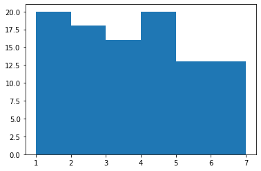

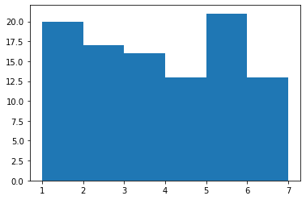

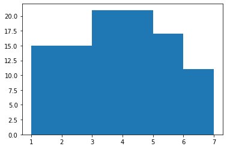

```
Done!
```

```python
i = 0
while i < 3:
    current_roll_100 = np.random.randint(1, 7, 100)
    plt.hist(current_roll_100, bins=range(1,8))
    plt.show()
    i = i + 1
print("Done!")
```

## Now smash that sample size increase button

## N = 1,000

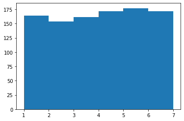

```python
plt.hist(np.random.randint(1, 7, 1000), bins=range(1,8))
plt.show()
```

Again, getting super tired of writing this same basic code over and over again... wonder if there's ANOTHER thing we learned that could help us here?

```python
def plot_dice_rolls(N):
    rolls_N = np.random.randint(1, 7, N)
    plt.hist(rolls_N, bins=range(1,8))
    plt.show()
```

## N = 10,000

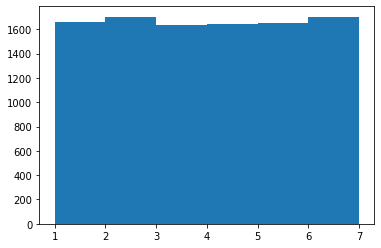

```python
plot_dice_rolls(10000)
```

## N = 100,000

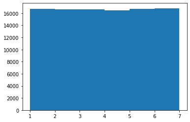

```python
plot_dice_rolls(100000)
```

## N = 1 Million

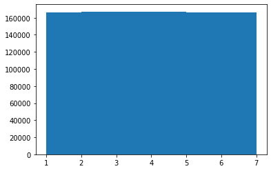

```python
plot_dice_rolls(1000000)
```

## Recall the Probability Distribution...

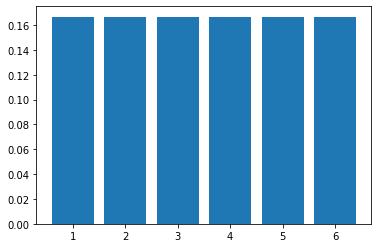

```python
plot_distribution()
```